# Lab 5

Random Forests/Bagging

Ashley L. Miller

11/21/2020

## Data

Read in the `train.csv` data.

- Because some of the models will take some time run, randomly sample 1% of the data (be sure to use `set.seed`).
- Remove the *classification* variable.

Read in the `fallmembershipreport_20192020.xlsx` data.

- Select `Attending School ID`, `School Name`, and all columns that represent the race/ethnicity percentages for the schools (there is example code in recent class slides).

Join the two data sets.

If you have accessed outside data to help increase the performance of your models for the final project (e.g., [NCES](https://nces.ed.gov/)), you can read in and join those data as well.

```r
#Import merged data that we saved out already
set.seed(3000)
data <- import(here::here("data", "data.csv"), setclass = "tbl_df") %>%
  janitor::clean_names() %>%
  sample_frac(.01)

head(data)
```

```
## # A tibble: 6 x 53
##       id gndr  ethnic_cd attnd_dist_inst… attnd_schl_inst… enrl_grd calc_admn_cd
##    <int> <chr> <chr>                <int>            <int>    <int> <lgl>
## 1 206903 M     W                     2256             1232        3 NA
## 2 249143 F     W                     2041              380        8 NA
## 3 186702 F     A                     2242             1136        4 NA
## 4 129731 M     W                     2204             1032        5 NA
## 5  44977 F     W                     2180              885        6 NA
## 6 210973 M     W                     1976             1308        5 NA
## # … with 46 more variables: tst_bnch <chr>, tst_dt <chr>, migrant_ed_fg <chr>,
## #   ind_ed_fg <chr>, sp_ed_fg <chr>, tag_ed_fg <chr>, econ_dsvntg <chr>,
## #   ayp_lep <chr>, stay_in_dist <chr>, stay_in_schl <chr>, dist_sped <chr>,
## #   trgt_assist_fg <chr>, ayp_dist_partic <chr>, ayp_schl_partic <chr>,
## #   ayp_dist_prfrm <chr>, ayp_schl_prfrm <chr>, rc_dist_partic <chr>,
## #   rc_schl_partic <chr>, rc_dist_prfrm <chr>, rc_schl_prfrm <chr>,
## #   partic_dist_inst_id <int>, partic_schl_inst_id <int>, lang_cd <chr>,
## #   tst_atmpt_fg <chr>, grp_rpt_dist_partic <chr>, grp_rpt_schl_partic <chr>,
## #   grp_rpt_dist_prfrm <chr>, grp_rpt_schl_prfrm <chr>, score <int>,
## #   ncessch <dbl>, lat <dbl>, lon <dbl>, p_freelunch <dbl>,
## #   p_reducedlunch <dbl>, teachers <dbl>, titlei_status <chr>,
## #   nslp_status <chr>, virtual <chr>, sch_name <chr>,
## #   p_american_indian_alaska_native <dbl>, p_asian <dbl>,
## #   p_native_hawaiian_pacific_islander <dbl>, p_black_african_american <dbl>,
## #   p_hispanic_latino <dbl>, p_white <dbl>, p_multiracial <dbl>
```

## Split and Resample

Split joined data from above into a training set and test set, stratified by the outcome `score`.

Use 10-fold CV to resample the training set, stratified by `score`.

```r
set.seed(3000)
data_split <- initial_split(data, strata = "score")
data_train <- training(data_split)
data_test  <- testing(data_split)
data_train_cv <- vfold_cv(data_train, strata = "score")
```

## Preprocess

Create one `recipe` to prepare your data for CART, bagged tree, and random forest models.

This lab could potentially serve as a template for your **Premilinary Fit 2**, or your final model prediction for the **Final Project**, so consider applying what might be your best model formula and the necessary preprocessing steps.

```r
rec <- recipe(score ~ ., data_train) %>%
    step_mutate(tst_dt = lubridate::mdy_hm(tst_dt)) %>%
    update_role(contains("id"), ncessch, sch_name, new_role = "id vars") %>%
    step_novel(all_nominal()) %>%
    step_unknown(all_nominal()) %>%
    step_nzv(all_predictors(), freq_cut = 99/1) %>%
    step_normalize(all_numeric(), -all_outcomes(), -has_role("id vars")) %>%
    step_BoxCox(all_numeric(), -all_outcomes(), -has_role("id vars")) %>%
    step_medianimpute(all_numeric(), -all_outcomes(), -has_role("id vars")) %>%
    step_dummy(all_nominal(), -has_role("id vars"), one_hot = TRUE) %>%
    step_zv(all_predictors())
```

## Decision Tree

1. Create a `parsnip` CART model using`{rpart}` for the estimation, tuning the cost complexity and minimum $n$ for a terminal node.

```r
dt_tune_mod <- decision_tree() %>%
  set_mode("regression") %>%
  set_engine("rpart") %>%
  set_args(cost_complexity = tune(),
           min_n = tune())
```

2. Create a `workflow` object that combines your `recipe` and your `parsnip` objects.

```r
dt_tune_workflow <- workflow() %>%
  add_recipe(rec) %>%
  add_model(dt_tune_mod)
```

3. Tune your model with `tune_grid`
- Use `grid = 10` to choose 10 grid points automatically
- In the `metrics` argument, please include `rmse`, `rsq`, and `huber_loss`
- Record the time it takes to run. You could use `{tictoc}`, or you could do something like:

```r
start_rf <- Sys.time()

set.seed(3000)

dt_tune_fit <- tune_grid(
  dt_tune_workflow,
  data_train_cv,
  grid = 10,
  metrics = yardstick::metric_set(rmse, rsq, huber_loss),
  control = tune::control_resamples(verbose = FALSE, #turn off for knitted doc
                                    save_pred = TRUE))

end_rf <- Sys.time()
end_rf - start_rf #1 minute
```

```
## Time difference of 1.156872 mins
```

4. Show the best estimates for each of the three performance metrics and the tuning parameter values associated with each.

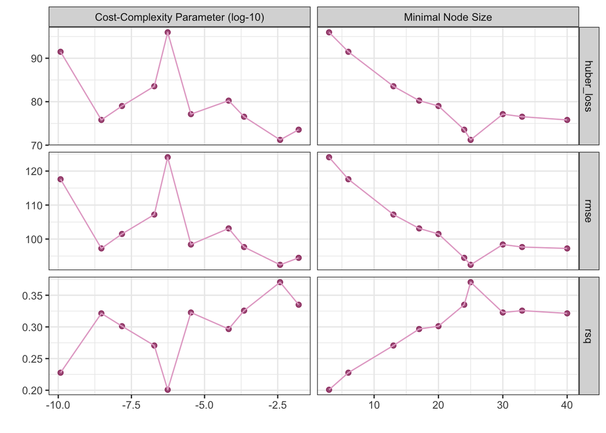

```r
dt_tune_fit %>%
  autoplot() +
  geom_line()
```

```r
show_best(dt_tune_fit, metric = "rmse", n = 1) #rmse = 92.4
```

```
## # A tibble: 1 x 8
##   cost_complexity min_n .metric .estimator  mean     n std_err .config
##             <dbl> <int> <chr>   <chr>      <dbl> <int>   <dbl> <chr>
## 1         0.00382    25 rmse    standard    92.4    10    2.02 Preprocessor1_Mo…
```

```r
show_best(dt_tune_fit, metric = "rsq", n = 1) #rsq = .371
```

```
## # A tibble: 1 x 8
##   cost_complexity min_n .metric .estimator  mean     n std_err .config
##             <dbl> <int> <chr>   <chr>      <dbl> <int>   <dbl> <chr>
## 1         0.00382    25 rsq     standard   0.371    10  0.0227 Preprocessor1_Mo…
```

```r
show_best(dt_tune_fit, metric = "huber_loss", n = 1) #huber loss = 71.2
```

```
## # A tibble: 1 x 8
##   cost_complexity min_n .metric   .estimator  mean     n std_err .config
##             <dbl> <int> <chr>     <chr>      <dbl> <int>   <dbl> <chr>
## 1         0.00382    25 huber_lo… standard    71.2    10    1.46 Preprocessor1_…
```

## Bagged Tree

1. Create a `parsnip` bagged tree model using`{baguette}`
- specify 10 bootstrap resamples (only to keep run-time down), and
- tune on `cost_complexity` and `min_n`

```r
bag_tune_mod <- bag_tree() %>%
  set_mode("regression") %>%
  set_engine("rpart", times = 10) %>% # 10 bootstrap re-samples
  set_args(cost_complexity = tune(),
           min_n = tune())
```

2. Create a `workflow` object that combines your `recipe` and your bagged tree model specification.

```r
bag_tune_workflow <- workflow() %>%
  add_recipe(rec) %>%
  add_model(bag_tune_mod)
```

3. Tune your model with `tune_grid`
- Use `grid = 10` to choose 10 grid points automatically
- In the `metrics` argument, please include `rmse`, `rsq`, and `huber_loss`
- In the `control` argument, please include `extract = function(x) extract_model(x)` to extract the model from each fit
- `{baguette}` is optimized to run in parallel with the `{future}` package. Consider using `{future}` to speed up processing time (see the class slides)
- Record the time it takes to run

#### **Question: Before you run the code, how many trees will this function execute?**

1,000 (10 folds * 10 grids * 10 trees)

```r
library(future)
plan(multisession)

library(tictoc)
tic()

set.seed(3000)

bag_tune_fit <- tune_grid(
  bag_tune_workflow,
  data_train_cv,
  grid = 10,
  metrics = yardstick::metric_set(rmse, rsq, huber_loss),
  control = tune::control_resamples(verbose = FALSE, #turn off for knitted doc
                                    save_pred = TRUE,
                                    extract = function(x) extract_model(x)))

toc() #about 4 min elapsed
```

```
## 255.31 sec elapsed
```

```r
plan(sequential)
```

4. Show the single best estimates for each of the three performance metrics and the tuning parameter values associated with each.

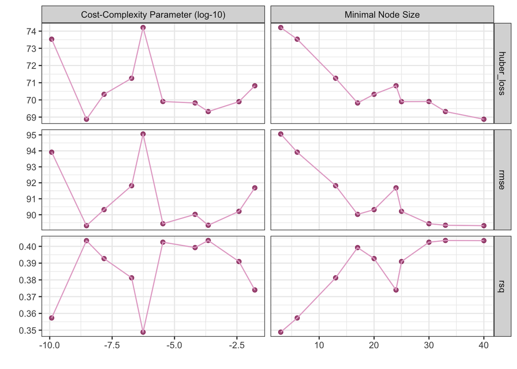

```r
bag_tune_fit %>%
  autoplot() +
  geom_line()
```

```r
show_best(bag_tune_fit, "rmse", n = 1) #rmse = 89.3
```

```
## # A tibble: 1 x 8
##   cost_complexity min_n .metric .estimator  mean     n std_err .config
##             <dbl> <int> <chr>   <chr>      <dbl> <int>   <dbl> <chr>
## 1   0.00000000297    40 rmse    standard    89.3    10    2.21 Preprocessor1_Mo…
```

```r
show_best(bag_tune_fit, "rsq", n = 1) #rsq = .404
```

```
## # A tibble: 1 x 8
##   cost_complexity min_n .metric .estimator  mean     n std_err .config
##             <dbl> <int> <chr>   <chr>      <dbl> <int>   <dbl> <chr>
## 1        0.000224    33 rsq     standard   0.404    10  0.0259 Preprocessor1_Mo…
```

```r
show_best(bag_tune_fit, "huber_loss", n = 1) #huber loss = 68.9
```

```
## # A tibble: 1 x 8
##   cost_complexity min_n .metric   .estimator  mean     n std_err .config
##             <dbl> <int> <chr>     <chr>      <dbl> <int>   <dbl> <chr>
## 1   0.00000000297    40 huber_lo… standard    68.9    10    1.53 Preprocessor1_…
```

5. Run the `bag_roots` function below. Apply this function to the extracted bagged tree models from the previous step. This will output the feature at the root node for each of the decision trees fit.

```r
bag_roots <- function(x){
  x %>%
  select(.extracts) %>%
  unnest(cols = c(.extracts)) %>%
  mutate(models = map(.extracts,
                  ~.x$model_df)) %>%
  select(-.extracts) %>%
  unnest(cols = c(models)) %>%
  mutate(root = map_chr(model,
                     ~as.character(.x$fit$frame[1, 1]))) %>%
  select(root)
}

(roots_bag_tune <- bag_roots(bag_tune_fit))
```

```
## # A tibble: 1,000 x 1
##    root
##    <chr>
##  1 tag_ed_fg_Y
##  2 tag_ed_fg_Y
##  3 tag_ed_fg_Y
##  4 tag_ed_fg_Y
##  5 econ_dsvntg_Y
##  6 enrl_grd
##  7 tag_ed_fg_Y
##  8 econ_dsvntg_N
##  9 tag_ed_fg_Y
## 10 tag_ed_fg_Y
## # … with 990 more rows
```

6. Produce a plot of the frequency of features at the root node of the trees in your bagged model.

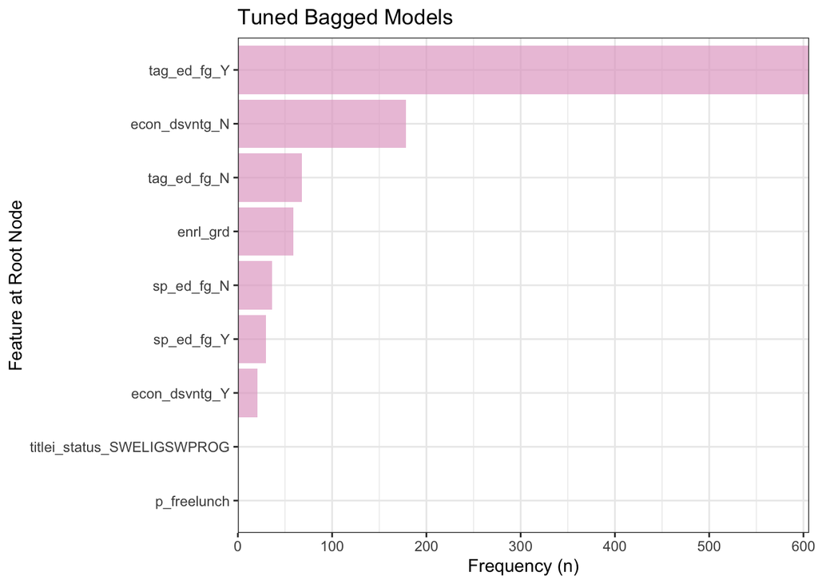

```r
roots_bag_tune %>%
  group_by(root) %>%
  count() %>%
  ggplot(aes(n, reorder(root, n))) +
  geom_col(fill = "#E4AACC",
           alpha = .70) +
  labs(y = "Feature at Root Node",
       x = "Frequency (n)",
       title = "Tuned Bagged Models") +
  scale_x_continuous(expand = c(0, 0))
```

## Random Forest

1. Create a `parsnip` random forest model using `{ranger}`
- use the `importance = "permutation"` argument to run variable importance
- specify 1,000 trees, but keep the other default tuning parameters

```r
(cores <- parallel::detectCores())
```

```
## [1] 4
```

```r
rf_mod <- rand_forest() %>%
  set_mode("regression") %>%
  set_engine("ranger",
             num.threads = cores,
             importance = "permutation",
             verbose = FALSE) %>% #turn off for knitted doc
  set_args(trees = 1000) #kept mtry and min_n as their defaults per instructions

#translate(rf_tune_mod)
```

2. Create a `workflow` object that combines your `recipe` and your random forest model specification.

```r
rf_workflow <-
  workflow() %>%
  add_model(rf_mod) %>%
  add_recipe(rec)
```

3. Fit your model
- In the `metrics` argument, please include `rmse`, `rsq`, and `huber_loss`
- In the `control` argument, please include `extract = function(x) x` to extract the workflow from each fit
- Record the time it takes to run

```r
tictoc::tic()

set.seed(3000)

rf_fit <- fit_resamples(
  rf_workflow,
  data_train_cv,
  metrics = yardstick::metric_set(rmse, rsq, huber_loss),
  control = control_resamples(verbose = FALSE, #turn off for knitted doc
                              save_pred = TRUE,
                              extract = function(x) x))

tictoc::toc() #45 seconds (took 9 minutes with tuning)
```

```
## 50.95 sec elapsed
```

4. Show the single best estimates for each of the three performance metrics.

```r
show_best(rf_fit, "rmse", n = 1) #rmse = 87.8
```

| .metric | .estimator | mean | n | std_err | .config |
| --- | --- | --- | --- | --- | --- |
| rmse | standard | 87.78833 | 10 | 1.811066 | Preprocessor1_Model1 |

```r
show_best(rf_fit, "rsq", n = 1) #rsq = .426
```

| .metric | .estimator | mean | n | std_err | .config |
| --- | --- | --- | --- | --- | --- |
| rsq | standard | 0.4263315 | 10 | 0.02022471 | Preprocessor1_Model1 |

```r
show_best(rf_fit, "huber_loss", n = 1) #huber loss = 67.7
```

| .metric | .estimator | mean | n | std_err | .config |
| --- | --- | --- | --- | --- | --- |
| huber_loss | standard | 67.73819 | 10 | 1.212379 | Preprocessor1_Model1 |

5. Run the two functions in the code chunk below. Then apply the `rf_roots` function to the results of your random forest model to output the feature at the root node for each of the decision trees fit in your random forest model.

```r
rf_tree_roots <- function(x){
  map_chr(1:1000,
           ~ranger::treeInfo(x, tree = .)[1, "splitvarName"])
}

rf_roots <- function(x){
  x %>%
  select(.extracts) %>%
  unnest(cols = c(.extracts)) %>%
  mutate(fit = map(.extracts,
                   ~.x$fit$fit$fit),
         oob_rmse = map_dbl(fit,
                         ~sqrt(.x$prediction.error)),
         roots = map(fit,
                        ~rf_tree_roots(.))
         ) %>%
  select(roots) %>%
  unnest(cols = c(roots))
}

(roots_rf_fit <- rf_roots(rf_fit))
```

| roots |
| --- |
| tst_bnch_X3B |
| titlei_status_SWELIGSWPROG |
| p_asian |
| p_reducedlunch |
| p_asian |
| econ_dsvntg_N |
| ethnic_cd_A |
| sp_ed_fg_N |
| tag_ed_fg_Y |
| sp_ed_fg_N |

[output cut: 9990 more lines]

6. Produce a plot of the frequency of features at the root node of the trees in your bagged model.

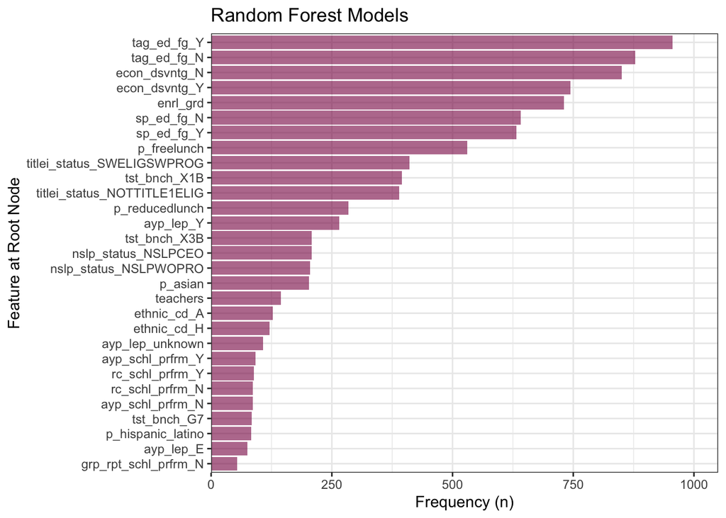

```r
roots_rf_fit %>%
  group_by(roots) %>%
  count() %>%
  filter(n > 50) %>% # I only want the top 25 or so
  ggplot(aes(n, reorder(roots, n))) +
  geom_col(fill = "#880E4F",
           alpha = .60) +
  labs(y = "Feature at Root Node",
       x = "Frequency (n)",
       title = "Random Forest Models") +
  scale_x_continuous(expand = c(0, 0),
                     limits = c(0, 1050))
```

7. **Please explain why the bagged tree root node figure and the random forest root node figure are different.**

*Bagged tree models* generally split at variables that are most relevant to predicting the outcome variable. For instance, most of the trees will use the strongest predictor in the top split; hence trees from different resamples generally have similar structure to each other (especially at the top of the tree). Conversely, *random forest models* aim to reduce underlying strong relations across trees by splitting at a root variable that is limited to a random subset of the original predictors (i.e., some of the strongest predictors may not be selected).

8. Apply the `fit` function to your random forest `workflow` object and your **full** training data. In class we talked about the idea that bagged tree and random forest models use resampling, and one *could* use the OOB prediction error provided by the models to estimate model performance.
- Record the time it takes to run

```r
# model used in workflow:
# rf_mod <- rand_forest() %>%
#   set_mode("regression") %>%
#   set_engine("ranger",
#              num.threads = cores,
#              importance = "permutation",
#              verbose = FALSE) %>% #turn off for knitted doc
#   set_args(trees = 1000) #kept mtry and min_n as their defaults per instructions

tictoc::tic()

set.seed(3000)

rf_oob_fit <- fit(rf_workflow,
                  data = data) #training data (down sampled to 1%) prior to any splitting

tictoc::toc() # 8 seconds
```

```
## 7.65 sec elapsed
```

- Extract the oob prediction error from your fitted object. If you print your fitted object, you will see a value for *OOB prediction error (MSE)*. You can take the `sqrt()` of this value to get the *rmse*. Or you can extract it by running: `sqrt(fit-object-name-here$fit$fit$fit$prediction.error)`.

```r
sqrt(rf_oob_fit$fit$fit$fit$prediction.error) #rmse = 87.07
```

```
## [1] 87.07344
```

- **How does OOB *rmse* here compare to the mean *rmse* estimate from your 10-fold CV random forest? How might 10-fold CV influence bias-variance?**

In this case, the OOB *rmse* (87.07) is actually quite similar to the *rmse* from our 10-fold cross validation random forest model (*rmse* = 87.8). Given how well the data are predicted, 10-fold cross validation appears to produce models with relatively low bias (i.e., high performance). The bias-variance trade-off would suggest that 10-fold cross validation may therefore have more variability. This makes sense considering the model fitting process repeats over 10 “folds”, and each fold contains a sample in which none of the observations are repeated.

## Compare Performance

**Consider the four models you fit: (a) decision tree, (b) bagged tree, (c) random forest fit on resamples, and (d) random forest fit on the training data. Which model would you use for your final fit? Please consider the performance metrics as well as the run time, and briefly explain your decision.**

For my final fit, I would select the random forest model fit on the training data. While both random forest models were superior to the decision tree and bagged tree models in both performance and time, the random forest fit on the training data surprisingly yielded the smallest *rmse* and only took 8 seconds to run (5x the speed of the random forest fit on resamples).

NOTE: for some reason, when I do not include set.seed(3000) prior to model fitting, my knitted document produces different numerical results than I obtain when running the models in my console. I’m not sure why this happened.